## # spatialMapData

### Part 1: Set up the environment

- Install the package
- If devtools is not installed, first install this package

```r
install.packages("devtools")
```

- Using devtools, install the development version of this data packages from github

```r
library(devtools)
install_github("jtlovell/spatialMapData")
```

- Load the package

```r
library(spatialMapData)
```

### Part 2: Overview:

#### The simplest purpose of this package is to provide data for lines and polygons that can simply be plotted in R

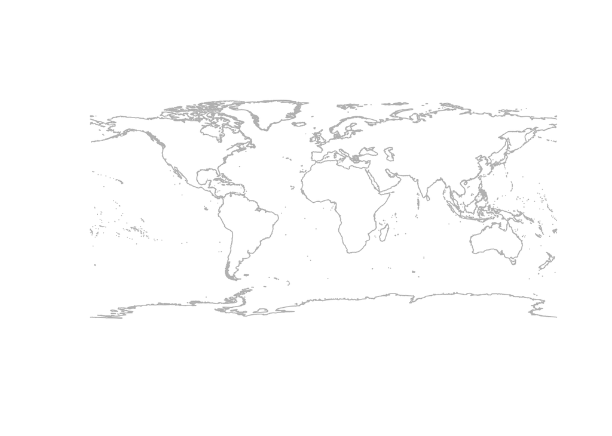

```r
data(ne_10m_coastline.shp)
plot(ne_10m_coastline.shp, col = "grey")
```

#### The data can also be cropped to a discrete region, for example the area around Vancouver, BC

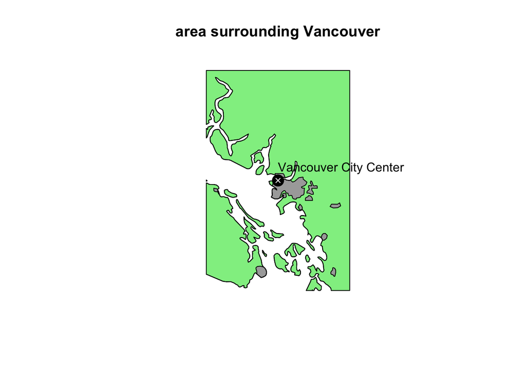

```r
extent <- c((-123.1207-1), (-123.1207+1), (49.2827-1), (49.2827+1))

plot(crop(ne_10m_land.shp,extent), col = "lightgreen")
title("area surrounding Vancouver")
data(ne_10m_urban_areas.shp)
plot(crop(ne_10m_urban_areas.shp,extent), add=T, col = "darkgrey")
plot(crop(ne_10m_coastline.shp,extent), add=T)
points(-123.1207, 49.2827, pch = 19, col = "black", cex = 2)
points(-123.1207, 49.2827, pch = 4, col = "white", cex = .75)
text(-123.1207, 49.2827, label = "Vancouver City Center", adj = c(0,-1))
```

#### The user may wish to make more complicated maps with points that come from one’s own data. Below is a workflow to do this.

### Part 3, Prepare the user defined data:

- Load some data that will be your spatial points
- Could also read in a csv or whatever
- Important that 1st two columns are latitude and longitude labeled as “lat” and “lon”

```r
ll<-data.frame(lat = c(35.99115, 42.41962, 31.04338,
                       32.30290, 27.54986, 38.89690, 39.14070,
                       30.28415, 30.38398, 41.15430, 44.30680),
               lon = c(-97.04649, -85.37127, -97.34950,
                       -94.97940, -97.88101, -92.21780,
                       -96.63890, -97.78162, -97.72938,
                       -96.41530, -96.67050),
               label = c("Stillwater", "Hickory Corners", "Temple",
                         "Overton", "Kingsville", "Columbia",
                         "Manhattan", "AustinBFL", "AustinPKLE",
                         "Lincoln", "Brookings"),
               stringsAsFactors=F)
```

```r
extent <- with(ll, c(min(lon-5), max(lon+5), min(lat-2), max(lat+2)))
sites <- SpatialPointsDataFrame(coords = ll[,c("lon","lat")], data=ll,
                               proj4string = CRS("+proj=longlat +datum=WGS84 +ellps=WGS84 +towgs84=0,0,0"))
sites.c <- crop(sites, extent)
```

- make a projection
- Here i use the extent data to inform the projection

```r
proj.parse<-paste0("+proj=poly +lat_0=",
                   mean(extent[3:4]),
                   " +lon_0=",
                   mean(extent[1:2]),
                   " +x_0=0 +y_0=0 +ellps=WGS84 +datum=WGS84 +units=m +no_defs")
proj <- CRS(proj.parse)
```

### Part 3 (Optional): Read in raster data from bioclim (or elsewhere)

- Not evaluated here to speed up compiling
- This layer can be cropped, projected and added to the plot like any other layer

```r
tmin<-getData('worldclim', var='bio', res=2.5)[["bio11"]]
tmin.c <- crop(tmin, extent)
```

### Part 4: Load the polygon / line / point files from the database

#### The package contains 15 processed shapefiles that have been transformed to uprojected spatialdataframes:

1. US Counties

```r
data(cb_2014_us_county_500k.shp)
```

2. Rivers

```r
data(MajorRivers_dd83.shp)
```

3. Country boundaries

```r
data(ne_10m_admin_0_boundary_lines_land.shp)
```

4. State/province boundaries

```r
data(ne_10m_admin_1_states_provinces.shp)
```

5. Coasts

```r
data(ne_10m_coastline.shp)
```

6. Lake borders

```r
data(ne_10m_lakes.shp)
```

7. Land borders

```r
data(ne_10m_land.shp)
```

8. Protected land borders

```r
data(ne_10m_parks_and_protected_lands_area.shp)
```

9. Protected rivers/coasts

```r
data(ne_10m_parks_and_protected_lands_line.shp)
```

10. Protected lands centerpoints

```r
data(ne_10m_parks_and_protected_lands_point.shp)
```

11. Protected lands rank data

```r
data(ne_10m_parks_and_protected_lands_scale_rank.shp)
```

12. Densely populated area boundaries

```r
data(ne_10m_populated_places.shp)
```

13. River centerlines

```r
data(ne_10m_rivers_lake_centerlines.shp)
```

14. Roads

```r
data(ne_10m_roads.shp)
```

15. Urban area boundaries

```r
data(ne_10m_urban_areas.shp)
```

### Part 5 Crop the .shp’s to the area of the ll data and USA

```r
states <- crop(ne_10m_admin_1_states_provinces.shp, extent)
lakes <- crop(ne_10m_lakes.shp, extent)
land <- crop(ne_10m_land.shp, extent)
urbanAreas <- crop(ne_10m_urban_areas.shp, extent)

us.states<-states[grep("USA",states[[1]]),]
```

### Part 6: Make unprojected map

#### Some notes:

- The initial plot (1st line) is the first layer
- All following layers need to specify add = T so that the layer is added to the existing plot

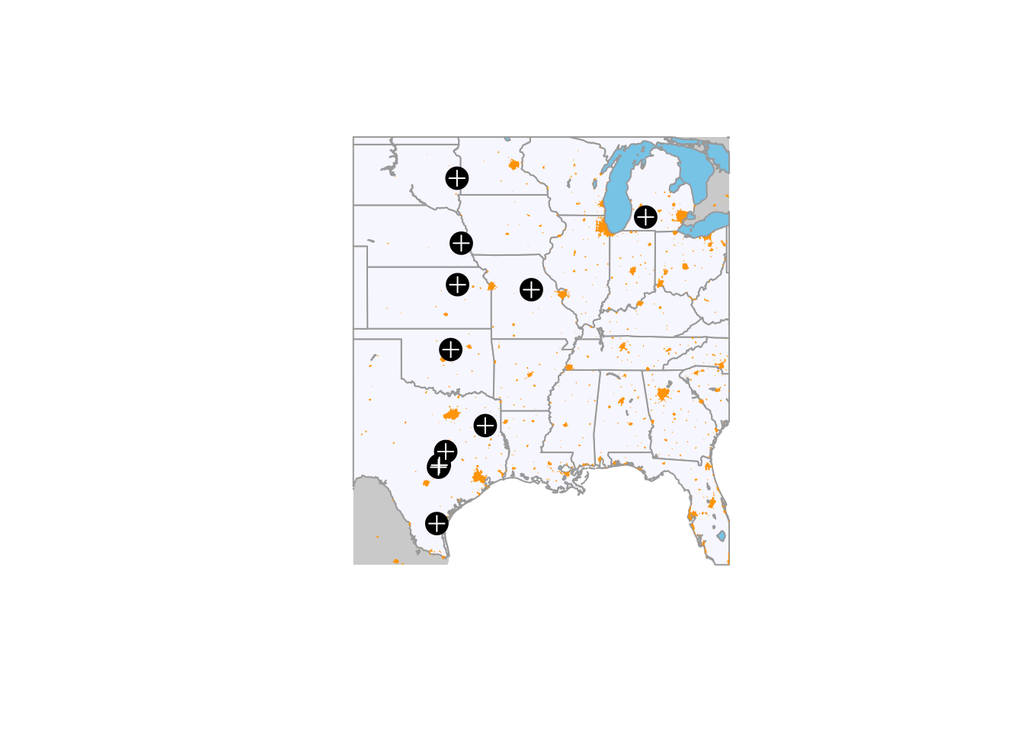

```r
plot(land, col = "lightgrey", bty="n", border = F)
plot(us.states, border="darkgrey", col = "ghostwhite", add=T)
plot(urbanAreas, col = "orange", add=T, border=F)
plot(lakes, col = "skyblue",border="darkgrey", add=T)
plot(sites.c, col = "black",pch=19, cex = 2, add=T)
plot(sites.c, col = "white", add=T)
```

### Part 7: Project the data

```r
us.states <- spTransform(us.states, proj)
land <- spTransform(land, proj)
urbanAreas <- spTransform(urbanAreas, proj)
sites.c <- spTransform(sites.c, proj)
lakes <- spTransform(lakes, proj)
```

### Part 8: Make a projected plot

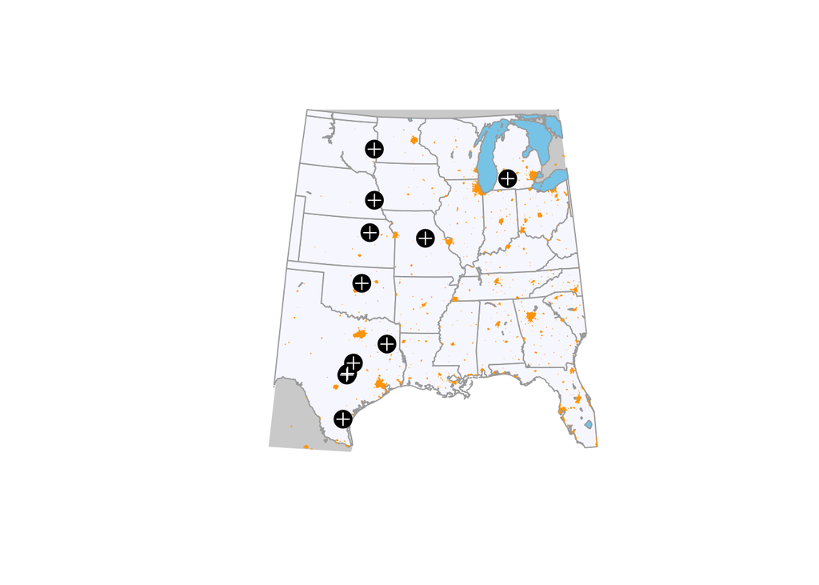

```r
plot(land, col = "lightgrey", bty="n", border = F)
plot(us.states, border="darkgrey", col = "ghostwhite", add=T)
plot(urbanAreas, col = "orange", add=T, border=F)
plot(lakes, col = "skyblue",border="darkgrey", add=T)
plot(sites.c, col = "black",pch=19, cex = 2, add=T)
plot(sites.c, col = "white", add=T)
```